# Reproducible Research: Peer Assessment 1

Neelanshi Varia

August 5, 2017

## Loading and preprocessing the data

```r
library(ggplot2)
myData <- read.csv("activity.csv")
```

## What is mean total number of steps taken per day?

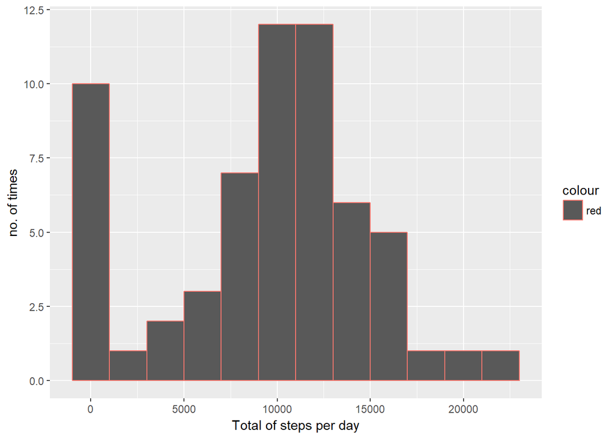

```r
total_per_day <- tapply(myData$steps, myData$date, FUN=sum, na.rm=TRUE)
qplot(total_per_day, binwidth = 2000, xlab="Total of steps per day", ylab = "no. of times", col = "red")
```

```r
mean(total_per_day, na.rm=TRUE) #finding mean of the steps
```

```
## [1] 9354.23
```

```r
median(total_per_day, na.rm=TRUE) #finding median of the steps
```

```
## [1] 10395
```

## What is the average daily activity pattern?

We will make a plot (i.e. type = “l”) of 5-minute intervals and the average number of steps taken averaged for all days.

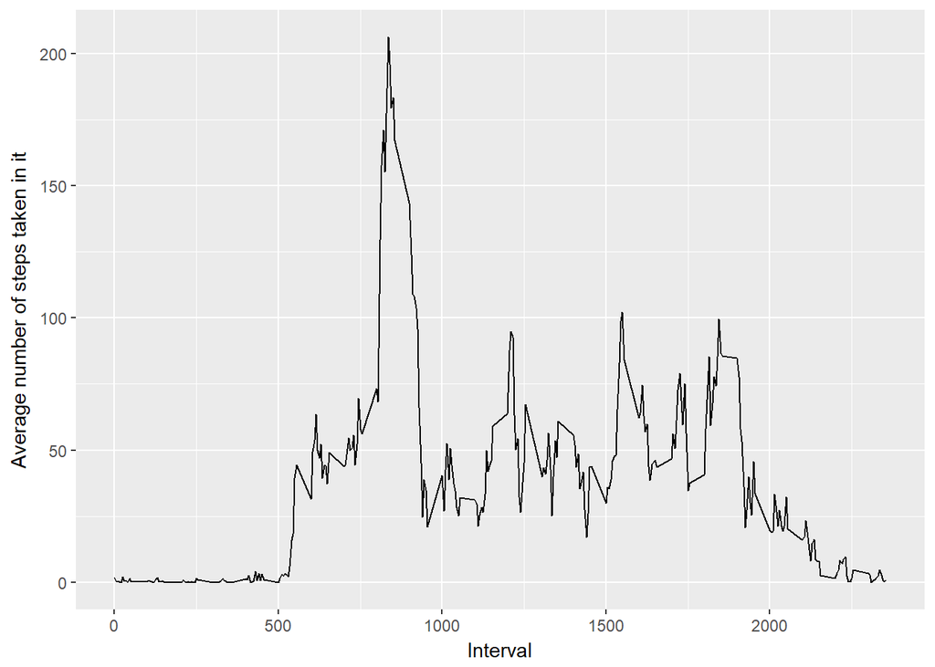

```r
avg <- aggregate(x=list(steps=myData$steps), by=list(interval=myData$interval),FUN=mean, na.rm=TRUE)
ggplot(data=avg, aes(x=interval, y=steps)) +
  geom_line() +
  xlab("Interval") +
  ylab("Average number of steps taken in it")
```

## Imputing missing values

There are many missing values in the dataset. Hence, we find a mechanism to solve the problem instead of removing the values because that affects the average. By the following chunk of code we see that there are 2304 missing number of values.

```r
impute <- sum(is.na(myData$steps))
impute
```

```
## [1] 2304
```

Now we create a new dataset where we will replace the NA values with mean for that particular interval/day.

```r
newSet <- myData
nas <- is.na(newSet$steps)
avg_interval <- tapply(newSet$steps, newSet$interval, mean, na.rm=TRUE, simplify = TRUE)
newSet$steps[nas] <- avg_interval[as.character(newSet$interval[nas])]
```

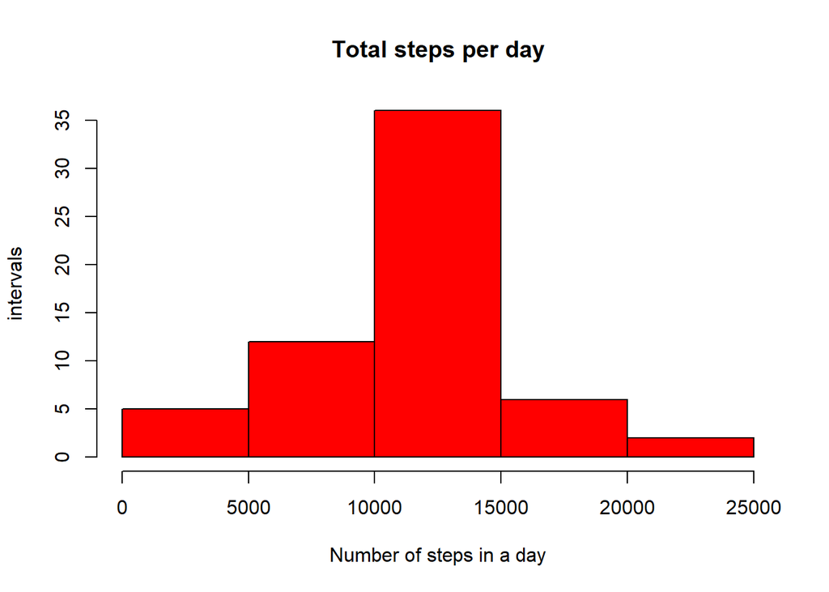

```r
new_total <- aggregate(steps ~ date, data = newSet, FUN = sum, na.rm = TRUE)
hist(new_total$steps, main = "Total steps per day", xlab = "Number of steps in a day",
    ylab = "intervals", col="red")
```

## Are there differences in activity patterns between weekdays and weekends?

Create a new factor variable in the dataset with two levels – “weekday” and “weekend” indicating whether a given date is a weekday or weekend day

```r
isWeekday <- function(date) {
  day <- weekdays(date)
  if (day %in% c("Monday", "Tuesday", "Wednesday", "Thursday", "Friday"))
    return("weekday")
  else
    return("weekend")
}
newSet$date <- as.Date(newSet$date)
newSet$day <- sapply(newSet$date, FUN=isWeekday)
```

Plotting the weekday and weekend result.

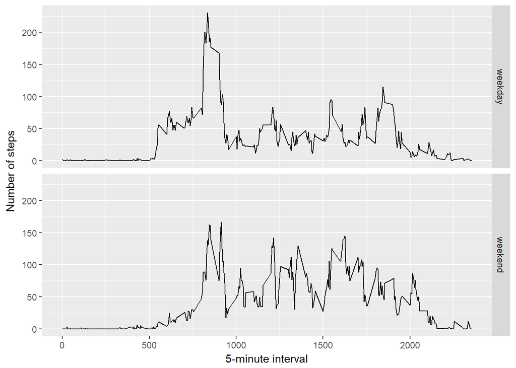

```r
avg <- aggregate(steps ~ interval + day, data=newSet, mean)
ggplot(avg, aes(interval, steps)) + geom_line() + facet_grid(day ~ .) +
  xlab("5-minute interval") + ylab("Number of steps")
```